# PSY8712 Week 8 Project

Merhar

2024-03-14

## Reproducible Image and Online Resources

An image of this project as of *14 March 2024* can be accessed by clicking [this link](https://mybinder.org/v2/gh/merha013/psy8712-week8/HEAD?urlpath=rstudio).

## Script Settings and Resources

```r
# setwd(dirname(rstudioapi::getActiveDocumentContext()$path))
library(rsconnect)
library(shiny)
library(shiny)
library(tinytex)
library(tidyverse)
```

## Data Import and Cleaning

```r
week8_tbl <- read_csv("../data/week3.csv") %>%
  mutate(timeStart = ymd_hms(timeStart),
         timeEnd = ymd_hms(timeEnd),
         timeSpent = as.numeric(timeEnd-timeStart),
         gender = recode_factor(gender,
                                M = "Male",
                                F = "Female"),
         condition = recode_factor(condition,
                                   A = "Block A",
                                   B = "Block B",
                                   C = "Control"),
         q5 = max(q5)-q5+1,
         average1 = (q1+q2+q3+q4+q5+q6)/6,  # probably a better way to do this, but (q1:q6) wasn't working for me
         average2 = (q8+q9+q10)/3) %>%
  filter(q6==1)
```

## Visualization

The following table shows the data contained in questions 1 through 6. It is paginated so that data is less overwhelming and shows only ten rows at a time.

| q1 | q2 | q3 | q4 | q5 | q6 |
| --- | --- | --- | --- | --- | --- |
| 5 | 4 | 4 | 1 | 2 | 1 |
| 2 | 4 | 3 | 1 | 3 | 1 |
| 5 | 5 | 2 | 1 | 5 | 1 |
| 4 | 3 | 4 | 2 | 4 | 1 |
| 3 | 1 | 3 | 5 | 2 | 1 |
| 4 | 3 | 2 | 3 | 3 | 1 |
| 2 | 4 | 1 | 3 | 1 | 1 |
| 4 | 2 | 5 | 1 | 1 | 1 |
| 2 | 5 | 3 | 4 | 2 | 1 |
| 3 | 4 | 2 | 4 | 5 | 1 |

[output cut: 36 more lines]

The following scatterplot was created using the data from week8_tbl and putting the mean scores of questions 1-6 on the x-axis and the mean scores of questions 8-10 on the y-axis. A purple OLS regression line with a shaded error band is included in the depiction. Additionally, the input code to create this scatterplot has been hidden from the final output.

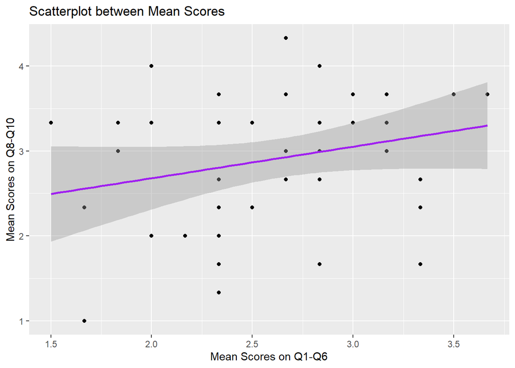

## Analysis

```
##
##  Pearson's product-moment correlation
##
## data:  week8_tbl$average1 and week8_tbl$average2
## t = 1.6735, df = 44, p-value = 0.1013
## alternative hypothesis: true correlation is not equal to 0
## 95 percent confidence interval:
##  -0.0491626  0.4994561
## sample estimates:
##       cor
## 0.2446267
```

I observed a correlation of 0.24 and a p-value of 0.1013217. This p-value means, using an $\alpha$=0.05, there is at least a 10.13217% probability of observing the collected data if there were truly no relationship between the mean of questions 1-6 and the mean of questions 8-10. Since 0.1013217 > $\alpha$, we fail to reject the null hypothesis that the true correlation is equal to 0. There is not enough evidence to conclude that there is a statistically significant relationship between the variables being tested at the 0.05 significance level.